# WGCNA

WGCNA analysis of CR gene expression in B. rapa RILs. See separate notebook for UN gene expression.

Lets start with some notes on what WGCNA is doing. (For more details, see [Zhang and Horvath, 2005](http://www.degruyter.com/view/j/sagmb.2005.4.1/sagmb.2005.4.1.1128/sagmb.2005.4.1.1128.xml;jsessionid=9F14E37B32BBAEB8DD0286D168168E7F) )

1. A correlation coefficient is calculated between all gene pairs.
2. This is converted to an adjacency matrix. Unlike typical adjacency matrices (which have values of 0, meaning not connected, or 1, meaning connected, based on some hard threshold) here the adjacency matrix can take any value from 0 to 1. Thus there is a soft threshold and the connectivity in the adjacency matrix is weighted by the correlations. Zhang and Horvath discuss different ways to relate the correlation matrix to the adjacency matrix, the default in WGCNA, and what I use, is a power function where the adjacency represent the correlation coefficient raised to some power $\beta$.
3. The power, $\beta$, is chosen such that the (weighted) connectivity shows a power law topology i.e. R2 of log10(p(k)) ~ log10(k) is > 0.9
4. Once an adjacency matrix is calculated the the similarity of nodes in the matrix is calculated using a topological overlap matrix (TOM). See Zhang and Horvath, 2005, for details. But basically a two nodes have a high TOM if they are connected to each other and to a similar set of other nodes.
5. To define modules genes are hiearchicaly clustered based on their distance (1-TOM) and a dynamic method is used to define cutoffs from this tree and the dissimilarity matrix. For more info see [here](https://labs.genetics.ucla.edu/horvath/htdocs/CoexpressionNetwork/BranchCutting/)
6. I tshould be noted that Zhang and Horvath provide formula to generalize most network calcualtions (i.e. connectivity, etc) from a 0,1 adjacency matrix to a 0-1 adjacency matrix.

```r
library(tidyverse)
library(WGCNA)
```

```r
library(ggplot2)
library(edgeR)
library(magrittr)
library(gplots)
options(stringsAsFactors = FALSE)
```

Get data

```r
#box_load(162362592785)
load("~/Box Sync/BrapaNetworks/Voom_CR_UN.Rdata")
annotation  <- read.csv("~/Box Sync/BrapaNetworks/Brapa_V1.5_annotated.csv.gz")
```

```r
RIL.coefs.CR <- grep("RIL",colnames(coef(voom.fit.CR)))
RIL.pvals.CR <- topTable(voom.fit.CR,coef = RIL.coefs.CR,number = Inf)
sum(RIL.pvals.CR$adj.P.Val<0.01)
```

```
## [1] 13903
```

```r
sum(RIL.pvals.CR$adj.P.Val<10e-05)
```

```
## [1] 8162
```

Start by taking the top 10000

```r
genes.of.interest.CR <- row.names(RIL.pvals.CR)[1:10000]
expr.data.CR <- voom.fit.CR$coefficients[genes.of.interest.CR,]
dim(expr.data.CR)
```

```
## [1] 10000   124
```

```r
head(expr.data.CR[,1:6])
```

```
##           (Intercept) pdata.CR$RILRIL_103 pdata.CR$RILRIL_104
## Bra016271  8.68333168           0.1309614          -6.5666021
## Bra035985  0.99705885           0.1727422           4.1021423
## Bra022069 -0.08034204          -0.2134252           6.2346213
## Bra040221  5.64722026          -0.2288833          -3.8419920
## Bra014438  3.71020663          -0.5362256           2.2519975
## Bra032770  6.23045147          -7.2320385          -0.2095483
##           pdata.CR$RILRIL_113 pdata.CR$RILRIL_115 pdata.CR$RILRIL_12
## Bra016271         -4.64724097          0.11402461         -6.0827513
## Bra035985         -0.02417053         -0.01133281          4.0109959
## Bra022069          1.09944954         -0.65449185          6.3305105
## Bra040221         -5.27077319         -5.78284163          0.1159076
## Bra014438          1.61149236          2.05457717         -5.8842582
## Bra032770         -5.20800675          0.31494052          0.4739283
```

```r
expr.data.CR[,-1] <- expr.data.CR[,-1] + expr.data.CR[,1] # add the intercept to the coefficients
colnames(expr.data.CR) <- sub("pdata.CR$RIL","",colnames(expr.data.CR),fixed=TRUE)
colnames(expr.data.CR)[1] <- "RIL_1"
head(expr.data.CR[,1:6])
```

```
##                 RIL_1    RIL_103  RIL_104   RIL_113    RIL_115    RIL_12
## Bra016271  8.68333168  8.8142930 2.116730 4.0360907  8.7973563  2.600580
## Bra035985  0.99705885  1.1698011 5.099201 0.9728883  0.9857260  5.008055
## Bra022069 -0.08034204 -0.2937673 6.154279 1.0191075 -0.7348339  6.250168
## Bra040221  5.64722026  5.4183369 1.805228 0.3764471 -0.1356214  5.763128
## Bra014438  3.71020663  3.1739810 5.962204 5.3216990  5.7647838 -2.174052
## Bra032770  6.23045147 -1.0015870 6.020903 1.0224447  6.5453920  6.704380
```

Get Rob’s Data

```r
blups2012 <- read.csv("~/Box Sync/BrapaNetworks/Brapa2012BayesHeight_blups.csv", row.names = 1)
blups2012$Line %<>% paste("RIL",.,sep="_")
blups2012 %<>% subset(select=!grepl("V1|individual|blk|trt|treat",colnames(.)))
head(blups2012)
```

| Line | UNr | CRr | UNHmax | CRHmax | UNInflection_DD | CRInflection_DD | UNInflection_size | CRInflection_size | UNduration | CRduration | UNSTP | CRSTP |
| --- | --- | --- | --- | --- | --- | --- | --- | --- | --- | --- | --- | --- |
| RIL_1 | 0.01265305 | 0.01294648 | 40.07475 | 35.68622 | 659.1968 | 616.8299 | 20.037377 | 17.843108 | 944.3922 | 887.0163 | 38.41570 | 34.27094 |
| RIL_2 | 0.01312970 | 0.01320636 | 49.99002 | 45.20347 | 661.9006 | 635.2602 | 24.995008 | 22.601736 | 917.1550 | 895.7425 | 48.01279 | 43.13936 |
| RIL_7 | 0.01368674 | 0.01445970 | 37.62779 | 33.04620 | 516.3685 | 494.4886 | 18.813894 | 16.523101 | 761.0105 | 750.1993 | 35.74825 | 31.68395 |
| RIL_9 | 0.01339133 | 0.01469806 | 29.83789 | 24.81520 | 545.0483 | 497.9265 | 14.918945 | 12.407598 | 800.6085 | 721.0262 | 28.78392 | 23.71262 |
| RIL_12 | 0.01447632 | 0.01550266 | 19.86868 | 19.65954 | 516.6281 | 492.9761 | 9.934341 | 9.829771 | 762.5616 | 727.8776 | 18.79155 | 18.73104 |
| RIL_15 | 0.01324382 | 0.01385887 | 47.85415 | 42.64318 | 616.4516 | 596.4780 | 23.927076 | 21.321591 | 876.2526 | 853.8673 | 46.63094 | 40.88605 |

```r
blups.CR <- blups2012 %>% select(starts_with("Line"),starts_with("CR"),-matches("Inflection_size"))
head(blups.CR)
```

| Line | CRr | CRHmax | CRInflection_DD | CRduration | CRSTP |
| --- | --- | --- | --- | --- | --- |
| RIL_1 | 0.01294648 | 35.68622 | 616.8299 | 887.0163 | 34.27094 |
| RIL_2 | 0.01320636 | 45.20347 | 635.2602 | 895.7425 | 43.13936 |
| RIL_7 | 0.01445970 | 33.04620 | 494.4886 | 750.1993 | 31.68395 |
| RIL_9 | 0.01469806 | 24.81520 | 497.9265 | 721.0262 | 23.71262 |
| RIL_12 | 0.01550266 | 19.65954 | 492.9761 | 727.8776 | 18.73104 |
| RIL_15 | 0.01385887 | 42.64318 | 596.4780 | 853.8673 | 40.88605 |

## WGCNA

### CR

transform

```r
head(expr.data.CR[,1:6])
```

```
##                 RIL_1    RIL_103  RIL_104   RIL_113    RIL_115    RIL_12
## Bra016271  8.68333168  8.8142930 2.116730 4.0360907  8.7973563  2.600580
## Bra035985  0.99705885  1.1698011 5.099201 0.9728883  0.9857260  5.008055
## Bra022069 -0.08034204 -0.2937673 6.154279 1.0191075 -0.7348339  6.250168
## Bra040221  5.64722026  5.4183369 1.805228 0.3764471 -0.1356214  5.763128
## Bra014438  3.71020663  3.1739810 5.962204 5.3216990  5.7647838 -2.174052
## Bra032770  6.23045147 -1.0015870 6.020903 1.0224447  6.5453920  6.704380
```

```r
expr.data.CR.t <- t(expr.data.CR)
head(expr.data.CR.t[,1:6])
```

```
##         Bra016271 Bra035985   Bra022069  Bra040221 Bra014438 Bra032770
## RIL_1    8.683332 0.9970589 -0.08034204  5.6472203  3.710207  6.230451
## RIL_103  8.814293 1.1698011 -0.29376729  5.4183369  3.173981 -1.001587
## RIL_104  2.116730 5.0992011  6.15427928  1.8052283  5.962204  6.020903
## RIL_113  4.036091 0.9728883  1.01910749  0.3764471  5.321699  1.022445
## RIL_115  8.797356 0.9857260 -0.73483390 -0.1356214  5.764784  6.545392
## RIL_12   2.600580 5.0080547  6.25016848  5.7631278 -2.174052  6.704380
```

check sample quality

```r
gag.CR <- goodSamplesGenes(expr.data.CR.t, verbose = 3)
```

```
##  Flagging genes and samples with too many missing values...
##   ..step 1
```

```r
gag.CR$allOK
```

```
## [1] TRUE
```

cluster samples to look for outliers

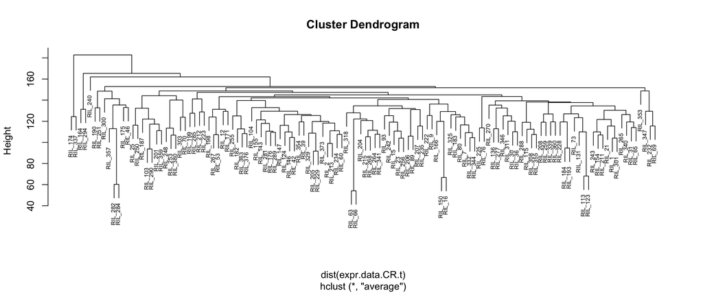

```r
sampleTREE.CR <- hclust(dist(expr.data.CR.t), method = "average")
plot(sampleTREE.CR,cex=.6)
```

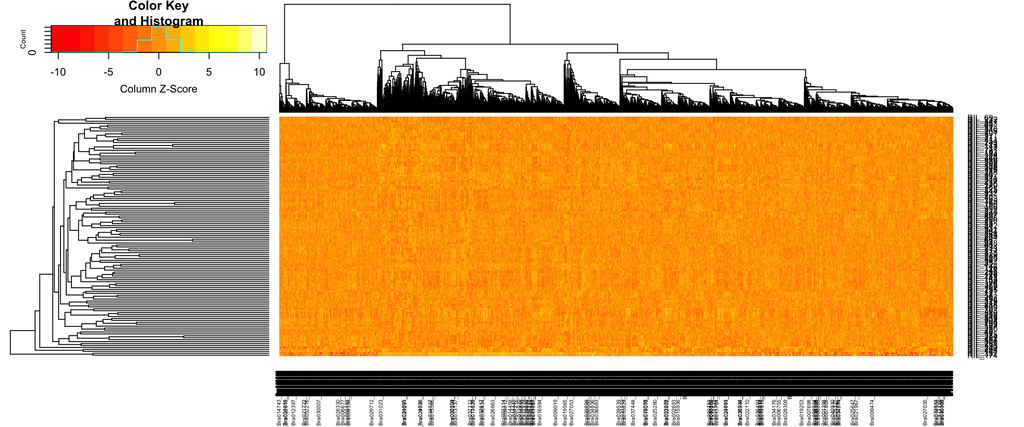

```r
heatmap.2(expr.data.CR.t,Rowv=as.dendrogram(sampleTREE.CR), scale="col", trace="none")
```

So a few samples are different but they don’t seem crazy different; leave them in for now.

Soft thresholding

```r
powers <- c(c(1:10), seq(from = 12, to=20, by=2))
sft <- pickSoftThreshold(expr.data.CR.t, powerVector = powers, verbose = 5)
```

```
## pickSoftThreshold: will use block size 4473.
##  pickSoftThreshold: calculating connectivity for given powers...
##    ..working on genes 1 through 4473 of 10000
```

```
##    ..working on genes 4474 through 8946 of 10000
##    ..working on genes 8947 through 10000 of 10000
##    Power SFT.R.sq  slope truncated.R.sq  mean.k. median.k. max.k.
## 1      1  0.00322 -0.176          0.916 1530.000  1.51e+03 2590.0
## 2      2  0.39600 -1.430          0.933  397.000  3.58e+02 1040.0
## 3      3  0.68500 -1.810          0.965  137.000  1.12e+02  508.0
## 4      4  0.82800 -1.870          0.991   57.800  4.36e+01  279.0
## 5      5  0.88800 -1.930          0.996   28.100  1.93e+01  170.0
## 6      6  0.89500 -2.040          0.994   15.200  9.50e+00  115.0
## 7      7  0.90000 -2.070          0.994    8.990  5.00e+00   81.8
## 8      8  0.90300 -2.010          0.990    5.690  2.79e+00   60.7
## 9      9  0.90500 -1.930          0.985    3.800  1.62e+00   46.4
## 10    10  0.92300 -1.790          0.979    2.670  9.66e-01   36.3
## 11    12  0.94000 -1.680          0.976    1.460  3.73e-01   25.7
## 12    14  0.91600 -1.690          0.970    0.893  1.56e-01   21.4
## 13    16  0.93400 -1.660          0.986    0.591  6.93e-02   18.2
## 14    18  0.95100 -1.610          0.997    0.415  3.21e-02   15.8
## 15    20  0.95400 -1.570          0.986    0.305  1.55e-02   13.9
```

```r
sizeGrWindow(9, 5)
par(mfrow = c(1,2))
cex1 <- 0.9
# Scale-free topology fit index as a fCRction of the soft-thresholding power
plot(sft$fitIndices[,1], -sign(sft$fitIndices[,3])*sft$fitIndices[,2],
     xlab="Soft Threshold (power)",ylab="Scale Free Topology Model Fit,signed R^2",type="n",
     main = paste("Scale independence"))
text(sft$fitIndices[,1], -sign(sft$fitIndices[,3])*sft$fitIndices[,2],
     labels=powers,cex=cex1,col="red")
# this line corresponds to using an R^2 cut-off of h
abline(h=0.90,col="red")
# Mean connectivity as a fCRction of the soft-thresholding power
plot(sft$fitIndices[,1], sft$fitIndices[,5],
     xlab="Soft Threshold (power)",ylab="Mean Connectivity", type="n",
     main = paste("Mean connectivity"))
text(sft$fitIndices[,1], sft$fitIndices[,5], labels=powers, cex=cex1,col="red")
```

choose 7

```r
softPower <- 7
adjacency <- adjacency(expr.data.CR.t, power = softPower)
# Turn adjacency into topological overlap
TOM <- TOMsimilarity(adjacency);
```

```
## ..connectivity..
## ..matrix multiplication..
## ..normalization..
## ..done.
```

```r
dissTOM <- 1-TOM
```

```r
# Call the hierarchical clustering fCRction
geneTree <- hclust(as.dist(dissTOM), method = "average")
# Plot the resulting clustering tree (dendrogram)
sizeGrWindow(12,9)
plot(geneTree, xlab="", sub="", main = "Gene clustering on TOM-based dissimilarity",
     labels = FALSE, hang = 0.04)
```

define modules

```r
# We like large modules, so we set the minimum module size relatively high:
minModuleSize <- 30;
# Module identification using dynamic tree cut:
dynamicMods <- cutreeDynamic(dendro = geneTree, distM = dissTOM,
                             deepSplit <- 2, pamRespectsDendro = FALSE,
                             minClusterSize = minModuleSize);
```

```
##  ..done.
```

```r
table(dynamicMods)
```

```
## dynamicMods
##    1    2    3    4    5    6    7    8    9   10   11   12   13   14   15
## 1407 1268  942  499  444  384  358  323  275  232  222  201  178  151  151
##   16   17   18   19   20   21   22   23   24   25   26   27   28   29   30
##  126  122  120  104  102  100   98   94   91   90   88   82   81   80   78
##   31   32   33   34   35   36   37   38   39   40   41   42   43   44   45
##   78   77   76   76   73   73   72   71   70   69   68   62   62   61   60
##   46   47   48   49   50   51   52   53   54
##   59   56   55   53   52   48   48   45   45
```

```r
# Convert numeric lables into colors
dynamicColors = labels2colors(dynamicMods)
table(dynamicColors)
```

```
## dynamicColors
##         bisque4           black            blue           brown
##              56             358            1268             942
##          brown4            cyan       darkgreen        darkgrey
##              59             151              98              91
##     darkmagenta  darkolivegreen      darkorange     darkorange2
##              76              76              88              60
##         darkred   darkslateblue   darkturquoise     floralwhite
##             100              55              94              61
##           green     greenyellow          grey60           ivory
##             444             222             122              62
##       lightcyan      lightcyan1      lightgreen lightsteelblue1
##             126              62             120              68
##     lightyellow         magenta   mediumpurple3    midnightblue
##             104             275              69             151
##    navajowhite2          orange      orangered4   paleturquoise
##              45              90              70              78
##  palevioletred3            pink           plum1           plum2
##              45             323              71              53
##          purple             red       royalblue     saddlebrown
##             232             384             102              80
##          salmon         salmon4         sienna3         skyblue
##             178              48              73              81
##        skyblue3       steelblue             tan        thistle1
##              72              78             201              48
##        thistle2       turquoise          violet           white
##              52            1407              77              82
##          yellow     yellowgreen
##             499              73
```

```r
# Plot the dendrogram and colors CRderneath
sizeGrWindow(8,6)
plotDendroAndColors(geneTree, dynamicColors, "Dynamic Tree Cut",
                    dendroLabels = FALSE, hang = 0.03,
                    addGuide = TRUE, guideHang = 0.05,
                    main = "Gene dendrogram and module colors")
```

merge similar modules

```r
# Calculate eigengenes
MEList <- moduleEigengenes(expr.data.CR.t, colors = dynamicColors)
MEs <- MEList$eigengenes
# Calculate dissimilarity of module eigengenes
MEDiss <- 1-cor(MEs);
# Cluster module eigengenes
METree <- hclust(as.dist(MEDiss), method = "average");
# Plot the result
sizeGrWindow(7, 6)
plot(METree, main = "Clustering of module eigengenes",
     xlab = "", sub = "")
```

merge with correlation > 0.8

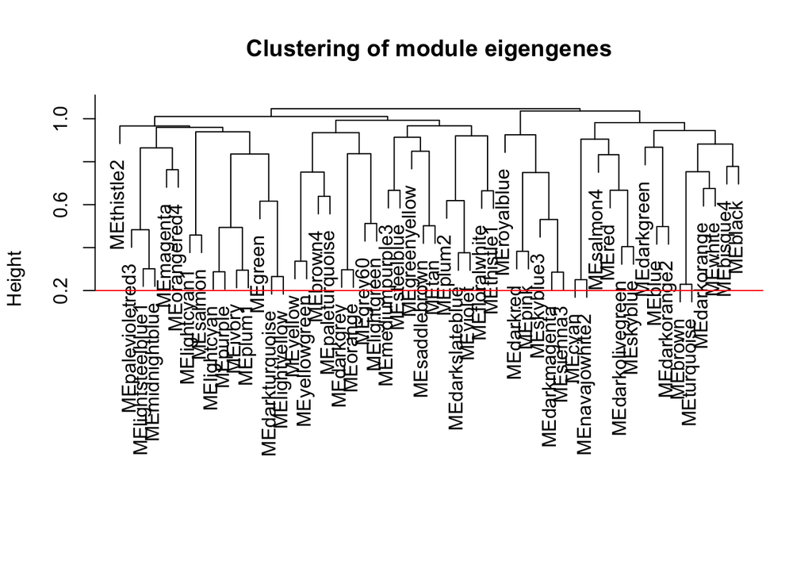

```r
MEDissThres = 0.2
# Plot the cut line into the dendrogram
plot(METree, main = "Clustering of module eigengenes",
     xlab = "", sub = "")
abline(h=MEDissThres, col = "red")
```

```r
# Call an automatic merging fCRction
merge = mergeCloseModules(expr.data.CR.t, dynamicColors, cutHeight = MEDissThres, verbose = 3)
```

```
##  mergeCloseModules: Merging modules whose distance is less than 0.2
##    multiSetMEs: Calculating module MEs.
##      Working on set 1 ...
##      moduleEigengenes: Calculating 54 module eigengenes in given set.
##    Calculating new MEs...
##    multiSetMEs: Calculating module MEs.
##      Working on set 1 ...
##      moduleEigengenes: Calculating 54 module eigengenes in given set.
```

```r
# The merged module colors
mergedColors = merge$colors
# Eigengenes of the new merged modules:
mergedMEs = merge$newMEs
table(merge$colors)
```

```
##
##         bisque4           black            blue           brown
##              56             358            1268             942
##          brown4            cyan       darkgreen        darkgrey
##              59             151              98              91
##     darkmagenta  darkolivegreen      darkorange     darkorange2
##              76              76              88              60
##         darkred   darkslateblue   darkturquoise     floralwhite
##             100              55              94              61
##           green     greenyellow          grey60           ivory
##             444             222             122              62
##       lightcyan      lightcyan1      lightgreen lightsteelblue1
##             126              62             120              68
##     lightyellow         magenta   mediumpurple3    midnightblue
##             104             275              69             151
##    navajowhite2          orange      orangered4   paleturquoise
##              45              90              70              78
##  palevioletred3            pink           plum1           plum2
##              45             323              71              53
##          purple             red       royalblue     saddlebrown
##             232             384             102              80
##          salmon         salmon4         sienna3         skyblue
##             178              48              73              81
##        skyblue3       steelblue             tan        thistle1
##              72              78             201              48
##        thistle2       turquoise          violet           white
##              52            1407              77              82
##          yellow     yellowgreen
##             499              73
```

```r
length(table(merge$colors))
```

```
## [1] 54
```

```r
median(table(merge$colors))
```

```
## [1] 81.5
```

compare pre and post merge

```r
sizeGrWindow(12, 9)
#pdf(file = "Plots/geneDendro-3.pdf", wi = 9, he = 6)
plotDendroAndColors(geneTree, cbind(dynamicColors, mergedColors),
c("Dynamic Tree Cut", "Merged dynamic"),
dendroLabels = FALSE, hang = 0.03,
addGuide = TRUE, guideHang = 0.05)
#dev.off()
```

```r
# Rename to moduleColors
moduleColors = mergedColors
# Construct numerical labels corresponding to the colors
colorOrder = c("grey", standardColors(50));
moduleLabels = match(moduleColors, colorOrder)-1;
MEs = mergedMEs
```

```r
head(MEs)
```

| MEthistle2 | MEpalevioletred3 | MElightsteelblue1 | MEmidnightblue | MEmagenta | MEorangered4 | MElightcyan1 | MEsalmon | MElightcyan | MEpurple | MEivory | MEplum1 | MEgreen | MEdarkturquoise | MElightyellow | MEyellow | MEyellowgreen | MEbrown4 | MEpaleturquoise | MEdarkgrey | MEorange | MEgrey60 | MElightgreen | MEmediumpurple3 | MEsteelblue | MEgreenyellow | MEsaddlebrown | MEtan | MEplum2 | MEdarkslateblue | … |
| --- | --- | --- | --- | --- | --- | --- | --- | --- | --- | --- | --- | --- | --- | --- | --- | --- | --- | --- | --- | --- | --- | --- | --- | --- | --- | --- | --- | --- | --- | --- |
| -0.10738024 | 0.07309933 | 0.11139029 | 0.09790077 | 0.09030063 | 0.10312271 | -0.03363138 | -0.118094114 | -0.090981605 | -0.07791999 | -0.07960771 | -0.08148625 | 0.05991151 | 0.06224352 | 0.08203171 | 0.09647650 | 0.00417073 | 0.11524694 | 0.10094178 | 0.10690366 | 0.10763313 | -0.089944731 | -0.08769369 | 0.10037847 | 0.08184847 | 0.06790145 | 0.03233087 | 0.12235258 | 0.08250437 | 0.07921118 | … |
| -0.08074363 | 0.09040843 | 0.08288745 | -0.07692452 | 0.09332651 | 0.11349373 | 0.02101005 | 0.053989882 | 0.089607444 | 0.09175066 | 0.09272399 | 0.10849661 | 0.03030602 | 0.02941290 | -0.03644739 | -0.02680472 | 0.01526319 | 0.13391092 | 0.11275784 | -0.08358256 | -0.04141930 | 0.067683832 | 0.11692087 | -0.08611031 | 0.10796237 | -0.11293717 | 0.11481292 | -0.09104923 | 0.07882424 | 0.07923028 | … |
| -0.09715735 | 0.10443239 | 0.08822989 | 0.09417851 | 0.08217085 | -0.04837099 | -0.10829597 | -0.074634707 | -0.080065761 | -0.07706632 | 0.09709764 | 0.10026762 | 0.03056632 | 0.03216216 | 0.04415339 | 0.11524899 | -0.05388110 | -0.09207388 | -0.07306067 | -0.08610525 | -0.07496898 | 0.087274157 | 0.10807780 | 0.14398832 | 0.11854635 | 0.16184192 | 0.06585674 | 0.12044538 | -0.12449235 | -0.09426606 | … |
| 0.07656743 | -0.07612456 | -0.08255509 | -0.08034568 | -0.09533532 | 0.09452574 | 0.04454402 | 0.049460869 | -0.085617026 | -0.07073560 | -0.09461480 | -0.06489283 | -0.14445288 | -0.09354384 | -0.13227280 | -0.14360552 | -0.11164552 | -0.06091511 | -0.09567533 | 0.11142689 | 0.10613039 | 0.079549091 | 0.03035216 | -0.05196486 | -0.08934936 | -0.08934944 | -0.07693248 | -0.05903391 | -0.08247711 | -0.10014843 | … |
| -0.11866533 | 0.09981980 | 0.09504553 | 0.08518807 | 0.10355549 | 0.10868756 | -0.12738194 | 0.008707838 | -0.004963135 | -0.08698002 | -0.08712992 | -0.08236737 | -0.02511102 | -0.10427960 | -0.04073585 | -0.02996606 | -0.03466678 | -0.09248147 | -0.09797962 | -0.08774747 | -0.07577093 | -0.002039237 | 0.09604957 | 0.10450015 | -0.06747574 | 0.14246994 | 0.11889499 | 0.08648121 | 0.06897292 | 0.08576016 | … |
| -0.11750933 | 0.10943485 | 0.05572476 | 0.07335818 | 0.07105973 | -0.08588765 | 0.07749060 | 0.080756881 | -0.098842862 | -0.09459537 | 0.08266582 | 0.09404279 | -0.14896101 | -0.09508990 | -0.06835922 | 0.01201055 | 0.17307558 | 0.11697636 | 0.04341556 | -0.09301725 | -0.06588370 | -0.116830481 | -0.04037322 | -0.11665251 | -0.09653454 | -0.07368258 | 0.11528022 | 0.13697857 | -0.09876060 | -0.09900060 | … |

```r
dim(MEs)
```

```
## [1] 124  54
```

```r
dim(blups.CR)
```

```
## [1] 121   6
```

```r
rownames(expr.data.CR.t)
```

```
##   [1] "RIL_1"   "RIL_103" "RIL_104" "RIL_113" "RIL_115" "RIL_12"  "RIL_123"
##   [8] "RIL_124" "RIL_131" "RIL_136" "RIL_143" "RIL_146" "RIL_147" "RIL_15"
##  [15] "RIL_150" "RIL_154" "RIL_155" "RIL_16"  "RIL_164" "RIL_166" "RIL_171"
##  [22] "RIL_174" "RIL_175" "RIL_176" "RIL_182" "RIL_183" "RIL_184" "RIL_187"
##  [29] "RIL_190" "RIL_193" "RIL_198" "RIL_199" "RIL_2"   "RIL_201" "RIL_204"
##  [36] "RIL_205" "RIL_206" "RIL_207" "RIL_208" "RIL_21"  "RIL_211" "RIL_212"
##  [43] "RIL_213" "RIL_215" "RIL_222" "RIL_223" "RIL_225" "RIL_228" "RIL_229"
##  [50] "RIL_23"  "RIL_232" "RIL_234" "RIL_235" "RIL_240" "RIL_242" "RIL_243"
##  [57] "RIL_248" "RIL_25"  "RIL_250" "RIL_251" "RIL_253" "RIL_255" "RIL_256"
##  [64] "RIL_259" "RIL_264" "RIL_265" "RIL_267" "RIL_268" "RIL_270" "RIL_277"
##  [71] "RIL_281" "RIL_282" "RIL_284" "RIL_285" "RIL_288" "RIL_289" "RIL_290"
##  [78] "RIL_294" "RIL_30"  "RIL_300" "RIL_301" "RIL_303" "RIL_308" "RIL_31"
##  [85] "RIL_311" "RIL_318" "RIL_325" "RIL_329" "RIL_332" "RIL_337" "RIL_339"
##  [92] "RIL_340" "RIL_341" "RIL_344" "RIL_346" "RIL_347" "RIL_353" "RIL_354"
##  [99] "RIL_355" "RIL_357" "RIL_359" "RIL_36"  "RIL_360" "RIL_363" "RIL_373"
## [106] "RIL_376" "RIL_380" "RIL_39"  "RIL_42"  "RIL_46"  "RIL_53"  "RIL_60"
## [113] "RIL_63"  "RIL_65"  "RIL_66"  "RIL_69"  "RIL_7"   "RIL_70"  "RIL_73"
## [120] "RIL_76"  "RIL_80"  "RIL_89"  "RIL_9"   "RIL_93"
```

```r
rownames(MEs)
```

```
##   [1] "1"   "2"   "3"   "4"   "5"   "6"   "7"   "8"   "9"   "10"  "11"
##  [12] "12"  "13"  "14"  "15"  "16"  "17"  "18"  "19"  "20"  "21"  "22"
##  [23] "23"  "24"  "25"  "26"  "27"  "28"  "29"  "30"  "31"  "32"  "33"
##  [34] "34"  "35"  "36"  "37"  "38"  "39"  "40"  "41"  "42"  "43"  "44"
##  [45] "45"  "46"  "47"  "48"  "49"  "50"  "51"  "52"  "53"  "54"  "55"
##  [56] "56"  "57"  "58"  "59"  "60"  "61"  "62"  "63"  "64"  "65"  "66"
##  [67] "67"  "68"  "69"  "70"  "71"  "72"  "73"  "74"  "75"  "76"  "77"
##  [78] "78"  "79"  "80"  "81"  "82"  "83"  "84"  "85"  "86"  "87"  "88"
##  [89] "89"  "90"  "91"  "92"  "93"  "94"  "95"  "96"  "97"  "98"  "99"
## [100] "100" "101" "102" "103" "104" "105" "106" "107" "108" "109" "110"
## [111] "111" "112" "113" "114" "115" "116" "117" "118" "119" "120" "121"
## [122] "122" "123" "124"
```

```r
rownames(MEs) <- rownames(expr.data.CR.t)
head(blups.CR)
```

| Line | CRr | CRHmax | CRInflection_DD | CRduration | CRSTP |
| --- | --- | --- | --- | --- | --- |
| RIL_1 | 0.01294648 | 35.68622 | 616.8299 | 887.0163 | 34.27094 |
| RIL_2 | 0.01320636 | 45.20347 | 635.2602 | 895.7425 | 43.13936 |
| RIL_7 | 0.01445970 | 33.04620 | 494.4886 | 750.1993 | 31.68395 |
| RIL_9 | 0.01469806 | 24.81520 | 497.9265 | 721.0262 | 23.71262 |
| RIL_12 | 0.01550266 | 19.65954 | 492.9761 | 727.8776 | 18.73104 |
| RIL_15 | 0.01385887 | 42.64318 | 596.4780 | 853.8673 | 40.88605 |

```r
ME.blups <- merge(blups.CR,MEs,by.x=1.,by.y=0)
head(ME.blups)
```

| Line | CRr | CRHmax | CRInflection_DD | CRduration | CRSTP | MEthistle2 | MEpalevioletred3 | MElightsteelblue1 | MEmidnightblue | MEmagenta | MEorangered4 | MElightcyan1 | MEsalmon | MElightcyan | MEpurple | MEivory | MEplum1 | MEgreen | MEdarkturquoise | MElightyellow | MEyellow | MEyellowgreen | MEbrown4 | MEpaleturquoise | MEdarkgrey | MEorange | MEgrey60 | MElightgreen | MEmediumpurple3 | … |
| --- | --- | --- | --- | --- | --- | --- | --- | --- | --- | --- | --- | --- | --- | --- | --- | --- | --- | --- | --- | --- | --- | --- | --- | --- | --- | --- | --- | --- | --- | --- |
| RIL_1 | 0.01294648 | 35.68622 | 616.8299 | 887.0163 | 34.27094 | -0.107380241 | 0.07309933 | 0.11139029 | 0.09790077 | 0.09030063 | 0.10312271 | -0.03363138 | -0.118094114 | -0.090981605 | -0.07791999 | -0.07960771 | -0.08148625 | 0.059911507 | 0.06224352 | 0.08203171 | 0.09647650 | 0.00417073 | 0.11524694 | 0.10094178 | 0.10690366 | 0.10763313 | -0.089944731 | -0.08769369 | 0.10037847 | … |
| RIL_103 | 0.01425524 | 42.58231 | 581.7151 | 826.9314 | 40.99773 | -0.080743635 | 0.09040843 | 0.08288745 | -0.07692452 | 0.09332651 | 0.11349373 | 0.02101005 | 0.053989882 | 0.089607444 | 0.09175066 | 0.09272399 | 0.10849661 | 0.030306024 | 0.02941290 | -0.03644739 | -0.02680472 | 0.01526319 | 0.13391092 | 0.11275784 | -0.08358256 | -0.04141930 | 0.067683832 | 0.11692087 | -0.08611031 | … |
| RIL_115 | 0.01394127 | 21.80572 | 629.6622 | 888.8281 | 20.72412 | -0.118665333 | 0.09981980 | 0.09504553 | 0.08518807 | 0.10355549 | 0.10868756 | -0.12738194 | 0.008707838 | -0.004963135 | -0.08698002 | -0.08712992 | -0.08236737 | -0.025111018 | -0.10427960 | -0.04073585 | -0.02996606 | -0.03466678 | -0.09248147 | -0.09797962 | -0.08774747 | -0.07577093 | -0.002039237 | 0.09604957 | 0.10450015 | … |
| RIL_12 | 0.01550266 | 19.65954 | 492.9761 | 727.8776 | 18.73104 | -0.117509327 | 0.10943485 | 0.05572476 | 0.07335818 | 0.07105973 | -0.08588765 | 0.07749060 | 0.080756881 | -0.098842862 | -0.09459537 | 0.08266582 | 0.09404279 | -0.148961010 | -0.09508990 | -0.06835922 | 0.01201055 | 0.17307558 | 0.11697636 | 0.04341556 | -0.09301725 | -0.06588370 | -0.116830481 | -0.04037322 | -0.11665251 | … |
| RIL_124 | 0.01241078 | 42.15245 | 720.1456 | 992.3727 | 39.94276 | -0.007448119 | -0.09129049 | -0.10671435 | -0.09830602 | 0.05438819 | -0.05162927 | -0.10232207 | 0.031337450 | 0.109531845 | 0.10089573 | 0.09474190 | 0.09357897 | 0.081382552 | -0.09786188 | -0.01392086 | 0.04496965 | 0.02944810 | -0.07777863 | -0.08594657 | 0.11117447 | 0.11091261 | 0.078117895 | 0.09420145 | -0.07311265 | … |
| RIL_131 | 0.01342325 | 23.18828 | 490.7085 | 750.4677 | 22.06499 | 0.083952731 | -0.11544227 | -0.09775896 | -0.10229846 | -0.07624274 | 0.09336220 | -0.02578687 | 0.020420537 | -0.098626116 | -0.07208619 | -0.07921157 | -0.08624936 | 0.003627213 | -0.01686661 | 0.05680784 | -0.09225831 | -0.04481078 | -0.06772430 | 0.08739992 | 0.10699786 | 0.11721889 | 0.022967372 | -0.08233920 | 0.08852555 | … |

```r
blups.cor <- cor(ME.blups[,2:6],ME.blups[,7:60])
```

```r
blups.cor.P <- corPvalueStudent(blups.cor,nrow(expr.data.CR.t))
blups.cor.sig <- blups.cor
blups.cor.sig[blups.cor.P>0.05] <- NA
blups.cor.sig
```

```
##                 MEthistle2 MEpalevioletred3 MElightsteelblue1
## CRr                     NA               NA        -0.3633113
## CRHmax           0.1818519               NA         0.3358741
## CRInflection_DD         NA               NA         0.4444746
## CRduration       0.1877648               NA         0.4600715
## CRSTP                   NA               NA         0.3380888
##                 MEmidnightblue MEmagenta MEorangered4 MElightcyan1
## CRr                 -0.2569962        NA   -0.2236266    0.1974247
## CRHmax               0.2570885        NA           NA           NA
## CRInflection_DD      0.2603549        NA           NA           NA
## CRduration           0.2683875        NA           NA           NA
## CRSTP                0.2585301        NA           NA           NA
##                 MEsalmon MElightcyan  MEpurple MEivory MEplum1    MEgreen
## CRr                   NA          NA        NA      NA      NA -0.5001882
## CRHmax                NA   0.2802640 0.1910197      NA      NA  0.5314728
## CRInflection_DD       NA          NA        NA      NA      NA  0.4352888
## CRduration            NA          NA        NA      NA      NA  0.4888703
## CRSTP                 NA   0.2849224 0.1963998      NA      NA  0.5261223
##                 MEdarkturquoise MElightyellow   MEyellow MEyellowgreen
## CRr                  -0.3061232    -0.3955156 -0.3225934            NA
## CRHmax                0.3856711     0.4440295  0.3508930            NA
## CRInflection_DD       0.3004963     0.4467384  0.3460533            NA
## CRduration            0.3294646     0.4688161  0.3699739            NA
## CRSTP                 0.3816496     0.4367351  0.3441033            NA
##                 MEbrown4 MEpaleturquoise MEdarkgrey   MEorange   MEgrey60
## CRr                   NA              NA -0.3499802 -0.2705045 -0.4181006
## CRHmax                NA              NA  0.2571532  0.2648538  0.2624178
## CRInflection_DD       NA              NA  0.2650434  0.3235093  0.2005759
## CRduration            NA              NA  0.3031176  0.3240278  0.2738095
## CRSTP                 NA              NA  0.2524576  0.2598244  0.2561470
##                 MElightgreen MEmediumpurple3 MEsteelblue MEgreenyellow
## CRr                       NA              NA   0.2207512            NA
## CRHmax                    NA              NA          NA            NA
## CRInflection_DD           NA              NA          NA            NA
## CRduration                NA              NA          NA            NA
## CRSTP                     NA              NA          NA            NA
##                 MEsaddlebrown      MEtan MEplum2 MEdarkslateblue MEviolet
## CRr                 0.2041915  0.1953823      NA              NA       NA
## CRHmax                     NA         NA      NA              NA       NA
## CRInflection_DD    -0.1944438         NA      NA              NA       NA
```

[output cut: 17 more lines]

```
## CRInflection_DD        NA         NA               NA        NA
## CRduration             NA         NA               NA        NA
## CRSTP                  NA -0.2175803               NA        NA
##                 MEdarkgreen     MEblue MEdarkorange2    MEbrown
## CRr                      NA  0.4135569     0.3784242         NA
## CRHmax           -0.2102093 -0.5563977    -0.4172007 -0.2857741
## CRInflection_DD          NA -0.4838581    -0.3212765 -0.3894973
## CRduration               NA -0.5102413    -0.3556218 -0.3653982
## CRSTP            -0.2091634 -0.5533732    -0.4139571 -0.2813374
##                 MEturquoise MEdarkorange    MEwhite MEbisque4  MEblack
## CRr               0.3243367           NA  0.4814367        NA 0.297579
## CRHmax           -0.4928267           NA -0.4542703        NA       NA
## CRInflection_DD  -0.6145206           NA -0.5767801        NA       NA
## CRduration       -0.5974727           NA -0.6011144        NA       NA
## CRSTP            -0.4847192           NA -0.4528443        NA       NA
```

plot it

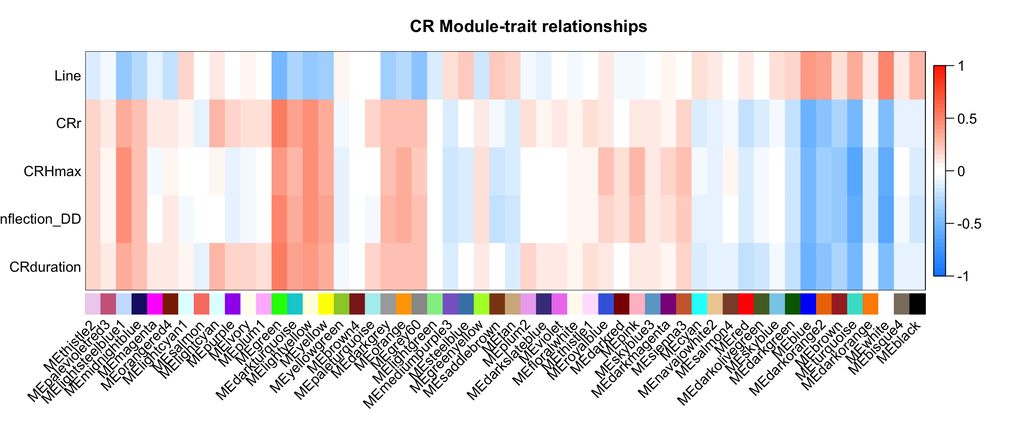

```r
# Will display correlations and their p-values
par(mar = c(8, 5, 3, 3));
# Display the correlation values within a heatmap plot
labeledHeatmap(Matrix = blups.cor,
               yLabels = names(blups.CR),
               xLabels = names(MEs),
               xSymbols = names(MEs),
               colorLabels = FALSE,
               colors = blueWhiteRed(50),
               #textMatrix = signif(blups.cor.P,2),
               setStdMargins = FALSE,
               cex.text = 0.5,
               zlim = c(-1,1),
               main = paste("CR Module-trait relationships"))
```

```r
pdf("Module-trait_heatmap_CR.pdf",height = 8,width = 12)
par(mar = c(8, 5, 3, 3));
# Display the correlation values within a heatmap plot
labeledHeatmap(Matrix = blups.cor,
               yLabels = names(blups.CR),
               xLabels = names(MEs),
               xSymbols = names(MEs),
               colorLabels = FALSE,
               colors = blueWhiteRed(50),
              # textMatrix = textMatrix,
               setStdMargins = FALSE,
               cex.text = 0.5,
               zlim = c(-1,1),
               main = paste("CR Module-trait relationships"))
dev.off()
```

Arbitrary, but let’s take the max and min for each trait (so long as they are significant)

```r
blups.cor.5 <- blups.cor.sig

cor.top <- t(apply(blups.cor.5,1,function(x) {
  maxx = max(x,na.rm=TRUE)
  minx = min(x,na.rm=TRUE)
  ifelse(x == maxx | x == minx, x, NA)
}
))


cor.top <- cor.top[,apply(cor.top,2,function(x) !all(is.na(x)))]
cor.top
```

```
##                    MEgreen MElightyellow     MEblue MEturquoise    MEwhite
## CRr             -0.5001882            NA         NA          NA  0.4814367
## CRHmax           0.5314728            NA -0.5563977          NA         NA
## CRInflection_DD         NA     0.4467384         NA  -0.6145206         NA
## CRduration       0.4888703            NA         NA          NA -0.6011144
## CRSTP            0.5261223            NA -0.5533732          NA         NA
```

```r
write.csv(cor.top,"Eigen_trait_cor_CR_.5_threshold.csv")
```

write the Eigen genes

```r
head(MEs[,colnames(cor.top)])
```

| MEgreen | MElightyellow | MEblue | MEturquoise | MEwhite |
| --- | --- | --- | --- | --- |
| 0.05991151 | 0.08203171 | -0.02975342 | -0.03979744 | -0.08280998 |
| 0.03030602 | -0.03644739 | -0.07398636 | 0.07101791 | -0.04711407 |
| 0.03056632 | 0.04415339 | -0.10518893 | -0.15600419 | -0.07469835 |
| -0.14445288 | -0.13227280 | 0.02158611 | 0.20991425 | 0.12238614 |
| -0.02511102 | -0.04073585 | 0.12192960 | -0.10029485 | -0.07670366 |
| -0.14896101 | -0.06835922 | 0.19902127 | -0.04879060 | -0.07306032 |

```r
write.csv(MEs[,colnames(cor.top)],"Top_Eigen_genes_CR.csv")
```

write all Eigen genes

```r
write.csv(MEs,"All_Eigen_genes_CR.csv")
```